# Chapter 8: Deadlocks

##### Introduction to Deadlocks

In a multiprogramming environment where multiple threads run concurrently, threads often need to use various system resources (like CPU cycles, files, or printers). A thread must **request** a resource, **use** it, and then **release** it. Problems arise when a thread requests a resource that isn't currently available—it must wait.

A **deadlock** occurs when a set of threads becomes permanently blocked because **each thread in the set is holding a resource and waiting for another resource that is held by a different thread in the same set**. It's a permanent state of waiting in a cycle. You saw this briefly in Chapter 6 as a "liveness failure"—a situation where a program fails to make progress.

**A Simple Analogy (The Kansas Train Law):** The book gives a perfect real-world example: an old Kansas law stated, "When two trains approach each other at a crossing, both shall come to a full stop and neither shall start up again until the other has gone." This creates a **deadlock**: Train A is waiting for Train B to go, and Train B is waiting for Train A to go. Neither can proceed.

**Why is This Chapter Important?** While operating systems provide the tools for concurrency (like locks), they typically **do not** automatically prevent or resolve deadlocks. It is the **programmer's responsibility** to design applications that avoid deadlock situations. This challenge is growing as we write more concurrent software for multicore systems.

## 8.1 System Model

### What is a Resource?

A computer system has a **finite number of resources** to be shared among competing threads. Resources are categorized into **types (or classes)**, and each type can have multiple, identical **instances**.

- **Examples of Resource Types:** CPU cycles, memory blocks, files, I/O devices (printers, network interfaces, DVD drives).
- **Example of Instances:** If a system has four CPUs, the resource type "CPU" has four instances. If it has two network cards, the resource type "network interface" has two instances.
- **Key Point:** For the purposes of resource allocation, all instances of a given type are considered **identical**. If a thread requests a printer, *any* available printer should satisfy the request. If not, then the resource types have been defined incorrectly (e.g., a color printer and a black-and-white printer should be different resource types).

### Synchronization Tools as Resources

The synchronization tools from Chapter 6 (**mutex locks and semaphores**) are also system resources. In modern programming, they are the **most common source of deadlocks**.

- **Definition:** Each lock is typically associated with protecting a specific data structure (e.g., one lock for a queue, another for a linked list). Therefore, **each unique lock is considered its own resource class instance**.
- **Scope of Discussion:** This chapter focuses on **kernel-managed resources** and deadlocks within a single process's threads. Deadlocks can also occur between processes using interprocess communication (IPC), but those are not managed by the kernel and are not covered here.

### The Standard Resource-Use Sequence

A thread must interact with a resource in a strict, three-step sequence:

1. **Request:** The thread asks for the resource. If the resource is available, it is granted immediately. If not (e.g., a mutex lock is held by another thread), the **requesting thread must wait** until it can acquire the resource.
2. **Use:** The thread operates on the resource. For a mutex lock, this means entering the critical section. For a printer, this means sending data.
3. **Release:** The thread gives up the resource so it becomes available for other threads.

### How the Operating System Manages Resources

- **System Calls:** The request and release operations are often implemented as **system calls** (e.g., `open()`/`close()` for files, `allocate()`/`free()` for memory, `wait()`/`signal()` on semaphores, `acquire()`/`release()` on mutex locks).
- **System Tables:** The operating system maintains a **system table** to track all resources. For each resource, it records:
  - Whether it is **free** or **allocated**.
  - If allocated, **which thread** it is allocated to.
- **Wait Queues:** If a thread requests a resource currently allocated to another thread, the OS can place the requesting thread into a **queue of threads waiting for that specific resource**.

### Formal Definition of a Deadlocked State

A set of threads is in a **deadlocked state** when **every thread in the set is waiting for an event that can be caused only by another thread in the same set**.

- The events we are concerned with are primarily **resource acquisition and release**.
- While we focus on logical resources (locks, semaphores, files), deadlocks can also arise from other events like data arriving on a network socket.

### Classic Illustration: The Dining Philosophers (Recap from Section 7.1.3)

**Go to Figure 7.1** (the dining philosophers diagram) for a visual.

- **Resources:** The chopsticks.
- **Scenario:** All five philosophers get hungry simultaneously. Each philosopher follows the rule: "Pick up the chopstick on your left first."
- **Result:** Each philosopher successfully grabs the chopstick on her left. Now, **no chopsticks remain available**. Every philosopher is now waiting, forever, for the chopstick on her right (which is held by the philosopher to her right) to become available. This is a perfect deadlock.

### The Programmer's Responsibility

Developers use synchronization tools (locks) to **prevent race conditions**. However, in acquiring and releasing these locks, if the order is not carefully managed, it can lead to **deadlock**. The operating system does not automatically prevent this; it is the **developer's duty to design deadlock-free programs**.

## 8.2 Deadlock in Multithreaded Applications

Before we learn how to identify and manage deadlocks, let's see a concrete example of how one can occur in a real multithreaded program using **POSIX mutex locks** (Pthreads).

### 1. Mutex Lock Basics (Pthreads Refresher)

- `pthread_mutex_init()` initializes a mutex lock in an **unlocked** state.
- `pthread_mutex_lock()` is called by a thread to **acquire** a mutex. If the mutex is already locked by another thread, the calling thread **blocks** (waits) until the mutex becomes available.
- `pthread_mutex_unlock()` is called by a thread to **release** a mutex it holds, making it available for other threads.

### 2. The Deadlock Scenario Setup

The code creates and initializes two mutex locks:

```
pthread_mutex_t first_mutex;
pthread_mutex_t second_mutex;
pthread_mutex_init(&first_mutex, NULL);
pthread_mutex_init(&second_mutex, NULL);
```

Two threads are then created:

- **`thread_one`** executes the function `do_work_one()`.
- **`thread_two`** executes the function `do_work_two()`. Both threads need access to **both mutex locks** to do their work.

### 3. The Problem: Opposing Lock Acquisition Order

**Go to Figure 8.1** to see the exact code.

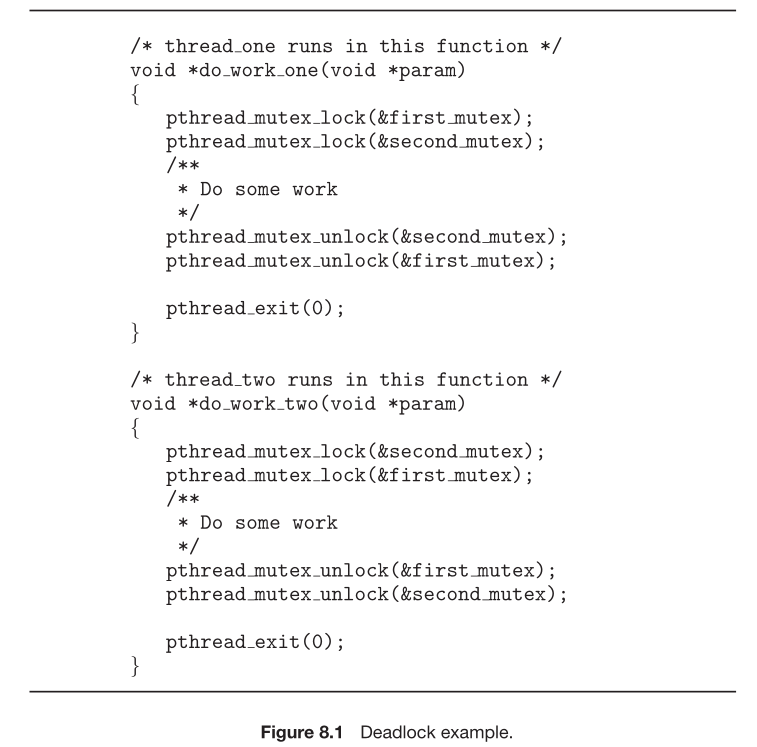

- **Thread One's Lock Order:**
  1. `pthread_mutex_lock(&first_mutex);` // Acquires **first_mutex**
  2. `pthread_mutex_lock(&second_mutex);` // Then tries to acquire **second_mutex**
- **Thread Two's Lock Order (OPPOSITE):**
  1. `pthread_mutex_lock(&second_mutex);` // Acquires **second_mutex**
  2. `pthread_mutex_lock(&first_mutex);` // Then tries to acquire **first_mutex**

### 4. How the Deadlock Happens (Step-by-Step)

This sequence leads to deadlock:

1. **Thread One** acquires `first_mutex`.
2. **Thread Two** acquires `second_mutex`. (These first two steps can happen concurrently).
3. Now:
   - **Thread One** tries to acquire `second_mutex`. It **blocks** because Thread Two holds it.
   - **Thread Two** tries to acquire `first_mutex`. It **blocks** because Thread One holds it.
4. Result: **Both threads are now permanently blocked, waiting for each other.** Thread One is waiting for a resource (`second_mutex`) held by Thread Two, and Thread Two is waiting for a resource (`first_mutex`) held by Thread One. This is a **deadlock**.

### 5. The Insidious Nature of Deadlocks

**Important Note:** Deadlock **may not always happen**. It depends entirely on **CPU scheduling timing** (a race condition).

- If **Thread One** runs quickly enough to acquire *and release* **both** `first_mutex` and `second_mutex` *before* **Thread Two** even starts trying to acquire locks, then no deadlock occurs.
- If the threads are interleaved just right (as described in step 4), deadlock occurs.

### 6. Key Takeaway for Developers

This example highlights the core challenge with deadlocks:

> **Deadlocks are non-deterministic and can be incredibly difficult to identify and test for**, because they may only manifest under very specific, timing-dependent scheduling scenarios. A program might run correctly 99 times out of 100 and deadlock on the 100th run, making debugging very hard.

The responsibility is on the programmer to design locking protocols that **avoid** the possibility of such circular waiting, which we will explore in the following sections.

### 8.2.1 Livelock

#### What is Livelock?

Livelock is another type of **liveness failure**, meaning the program fails to make forward progress. It is **similar to deadlock** in that two or more threads are prevented from proceeding, but the **reason** for the lack of progress is different.

- **Deadlock:** Threads are **blocked**, passively waiting for events that will never happen.
- **Livelock:** Threads are **not blocked**. They are actively executing code, but their actions continuously fail and result in no overall progress. They are "running in place."

#### The Hallway Analogy

Imagine two people trying to pass each other in a narrow hallway:

1. Person A moves to their right, while Person B moves to their left. They are still facing each other.
2. Seeing the obstruction, Person A moves to their left, while Person B moves to their right. They are *still* facing each other.
3. This dance repeats endlessly. **They are not stuck standing still (not blocked), but they are making no progress** down the hallway. This is livelock.

#### Livelock in Code: The `pthread_mutex_trylock()` Example

Livelock can be illustrated by modifying the previous deadlock example using the **`pthread_mutex_trylock()`** function.

- **What `pthread_mutex_trylock()` does:** It **attempts to acquire a mutex lock, but if the lock is unavailable, it fails immediately (returns an error code) instead of blocking.** This allows a thread to do other work instead of waiting.

**Go to Figure 8.2** (which rewrites the code from Figure 8.1).

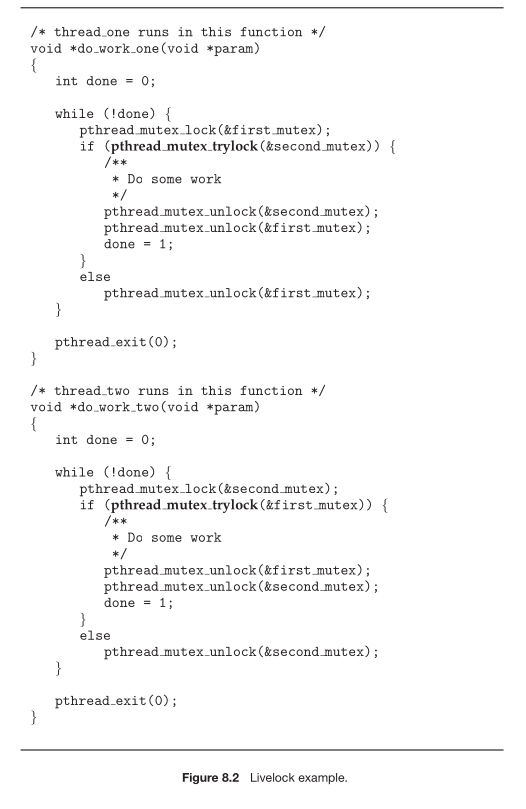

##### How Livelock Occurs in this Scenario:

1. **Thread One** acquires `first_mutex`.
2. **Thread Two** acquires `second_mutex`.
3. **The Loop Begins:**
   - **Thread One** calls `pthread_mutex_trylock(&second_mutex)`. This **fails** because Thread Two holds it. Thread One then **releases** `first_mutex`.
   - **Thread Two** calls `pthread_mutex_trylock(&first_mutex)`. This **fails** because Thread One *just* held it. Thread Two then **releases** `second_mutex`.
4. Both threads loop and try again. Now, they might acquire the *opposite* mutexes first (Thread One gets `second_mutex`, Thread Two gets `first_mutex`), and the `trylock` on the other mutex will fail again, causing them to release and restart.
5. Result: The threads are **actively running code, releasing and acquiring locks, but they never successfully acquire *both* locks at the same time to do their actual work.** They are livelocked.

#### How to Avoid Livelock

Livelock typically happens because threads **retry failing operations in perfect synchronization.**

- **The Solution:** Break the synchronization by introducing **randomness**.
- **Technique:** When an operation (like `trylock`) fails, have the thread wait for a **random duration** before retrying. This makes it highly likely that one thread will succeed while the other is waiting.
- **Real-World Example: Ethernet's Exponential Backoff.** When two network hosts detect a packet **collision**, they do not retransmit immediately. Instead, each host waits for a **randomly chosen backoff period** before trying again. This protocol is specifically designed to avoid livelock on the network.

#### Summary of Livelock

- **Less common** than deadlock but remains a **challenging issue** in concurrent application design.
- Like deadlock, it may only occur under **specific, timing-dependent scheduling circumstances**, making it difficult to test for and reproduce.
- The key differentiator from deadlock: threads are in an **active, endless loop** of failing operations, not a passive wait state.

## 8.3 Deadlock Characterization

We have seen how deadlock happens in code. Now, we formally define the **four necessary conditions** that must *all* be present simultaneously for a deadlock to occur. Understanding these conditions is crucial because **preventing deadlock involves negating at least one of them.**

### 8.3.1 Necessary Conditions for Deadlock

#### 1. Mutual Exclusion

**Definition:** At least one resource must be held in a **non-sharable** mode. This means that only one thread can use the resource at a time.

- **Consequence:** If another thread requests that resource, it must be delayed until the current holder **voluntarily releases** it.
- **Example:** A mutex lock is the perfect example. If Thread A has locked `mutex_X`, Thread B cannot use `mutex_X` until Thread A unlocks it.

#### 2. Hold and Wait

**Definition:** A thread must be **holding at least one resource** already and simultaneously be **waiting to acquire one or more *additional* resources** that are currently held by other threads.

- **Consequence:** Threads are not just waiting idly; they are holding resources hostage while waiting for more. This prevents other threads from using the held resources.
- **Example (from Figure 8.1):** Thread One holds `first_mutex` (it's holding) and is waiting for `second_mutex` (it's waiting). Thread Two holds `second_mutex` and is waiting for `first_mutex`.

#### 3. No Preemption

**Definition:** Resources **cannot be forcibly taken away (preempted)** from a thread. A resource can only be released **voluntarily** by the thread holding it, after that thread has finished its task.

- **Consequence:** You cannot simply break a deadlock by grabbing a lock from one thread and giving it to another. The thread must give it up on its own.
- **Contrast with CPU Preemption:** The CPU itself can be preempted (taken away) by the OS scheduler, but resources like locks and I/O devices typically operate under a no-preemption policy.

#### 4. Circular Wait

**Definition:** There must exist a **closed chain (circle) of waiting threads**. A set of waiting threads `{T0, T1, ..., Tn}` exists such that:

- `T0` is waiting for a resource held by `T1`.
- `T1` is waiting for a resource held by `T2`.
- ...
- `Tn-1` is waiting for a resource held by `Tn`.
- `Tn` is waiting for a resource held by `T0`.
- **Consequence:** Every thread in the circle is waiting for the next one, forming a cycle of dependency with no start or end point. No thread can proceed because each is waiting for another in the circle.
- **Example (from Figure 8.1):** The two-thread case: Thread One (T1) waits for a resource held by Thread Two (T2), and Thread Two (T2) waits for a resource held by Thread One (T1). This is a circular wait with two threads.

### Important Notes on the Conditions

1. **All Four Are Necessary:** Deadlock **cannot** occur if even *one* of these conditions is absent. Therefore, to prevent deadlock, we need to ensure at least one condition is **never allowed to hold**.
2. **Dependency Between Conditions:** The **Circular Wait** condition actually implies the **Hold and Wait** condition (if there's a circle of threads waiting, each thread in that circle must be holding a resource while waiting). So, the four conditions are not completely independent.
3. **Why Separate Them Anyway?** As we will see in Section 8.5, it is still very useful to think about them separately because each one suggests a different **strategy for attacking the deadlock problem** (prevention, avoidance, detection).

### Visualizing Deadlock: The Resource-Allocation Graph

**Go to Figure 8.3.** This figure presents a **Resource-Allocation Graph** for the deadlock program in Figure 8.1.

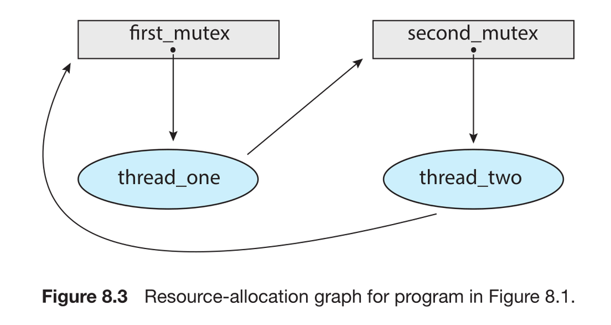

- **What it shows:** A visual model with two types of nodes:
  - **Thread Nodes** (represented as circles, e.g., `thread_one`, `thread_two`).
  - **Resource Nodes** (represented as rectangles, e.g., `first_mutex`, `second_mutex`). Dots inside the rectangle represent instances (one dot per instance).
- **How to read it:**
  - An **assignment edge** (resource → thread) means the resource is currently *held by* that thread.
  - A **request edge** (thread → resource) means the thread is *waiting for* that resource.
- **Deadlock Indicator:** The graph in Figure 8.3 has a **cycle** (`thread_one` → `second_mutex` → `thread_two` → `first_mutex` → `thread_one`). **If every resource in the cycle has only one instance (like a mutex), then the presence of a cycle in the graph means there is a deadlock.**

### 8.3.2 Resource-Allocation Graph

The Resource-Allocation Graph (RAG) is a **directed graph** that gives us a precise, visual model to describe the state of resource allocation and requests in a system. It is a crucial tool for **analyzing potential deadlocks**.

#### Graph Structure: Vertices (V) and Edges (E)

The graph consists of a set of vertices **V** and a set of edges **E**.

- **Vertices (V):** Divided into two disjoint sets:
  1. **Thread Nodes, T = {T₁, T₂, ..., Tₙ}:** Represented as **circles**. These are all the active threads in the system.
  2. **Resource Type Nodes, R = {R₁, R₂, ..., Rₘ}:** Represented as **rectangles**. These are all the different resource types in the system (e.g., Printer, Scanner, Mutex_A). Inside each rectangle, we draw a number of **dots** to represent the **instances** of that resource type (e.g., 2 dots for a system with 2 printers).
- **Edges (E):** Directed edges (arrows) represent relationships between threads and resources.
  1. **Request Edge:** A directed edge from thread **Tᵢ** to resource type **Rⱼ** (**Tᵢ → Rⱼ**). This means thread Tᵢ has **requested** an instance of resource type Rⱼ and is **currently waiting** for it.
  2. **Assignment Edge:** A directed edge from resource type **Rⱼ** to thread **Tᵢ** (**Rⱼ → Tᵢ**). This means an **instance** of resource type Rⱼ has been **allocated to** (is currently held by) thread Tᵢ. Importantly, this edge must originate from **a specific dot** inside the resource rectangle to show which exact instance is assigned.

#### Dynamic Behavior: How the Graph Changes

The graph is not static; it evolves as threads act:

1. **On a Request:** When thread Tᵢ requests an instance of resource Rⱼ, a **request edge** (Tᵢ → Rⱼ) is added to the graph.
2. **On a Grant:** When the request can be fulfilled (an instance becomes available), the request edge is **instantaneously transformed** into an **assignment edge** (Rⱼ → Tᵢ) from an available dot.
3. **On a Release:** When thread Tᵢ releases an instance of resource Rⱼ, the **assignment edge** (Rⱼ → Tᵢ) is **deleted** from the graph.

#### Interpreting the Graph: Cycles and Deadlock

The core purpose of the graph is to analyze the presence of **deadlock** by looking for **cycles**.

##### Case 1: Graph Contains NO Cycles

- **Conclusion:** If the resource-allocation graph **contains no cycles**, then **no thread in the system is deadlocked**. The system is in a safe state.

##### Case 2: Graph Contains a Cycle - Single-Instance Resources

- **Scenario:** Each resource type involved in the cycle has **exactly one instance** (only one dot per rectangle).
- **Conclusion:** A cycle **is both a necessary and sufficient condition for deadlock**. If you see a cycle, a deadlock **has definitely occurred**. Every thread in the cycle is deadlocked.
- **Example: Go to Figure 8.3.** This is the simple 2-thread, 2-mutex deadlock. Each mutex is a single-instance resource. The cycle `T1→R2→T2→R1→T1` means deadlock.

##### Case 3: Graph Contains a Cycle - Multi-Instance Resources

- **Scenario:** The cycle involves resource types that have **several instances** (multiple dots per rectangle).
- **Conclusion:** A cycle is a **necessary but NOT sufficient condition for deadlock**. A cycle *may* indicate a deadlock, but it might *not*. Further analysis is needed.
- **Why?** Because even with a cycle, one of the threads not in the cycle might release an instance, which could then be allocated to a waiting thread in the cycle, **breaking the cycle**.

#### Detailed Graph Analysis with Examples

**Example 1: Figure 8.4 (A Snapshot, No Deadlock)**

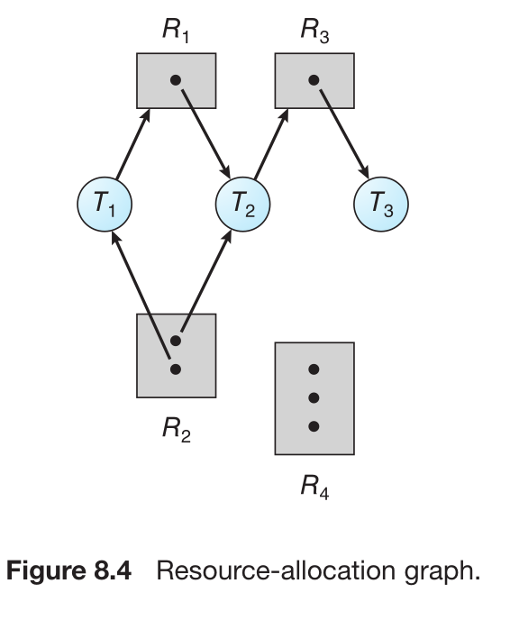

**Go to Figure 8.4.** Let's decode its state:

- **Vertices:** T = {T₁, T₂, T₃}; R = {R₁, R₂, R₃, R₄}.
- **Edges:** E = {T₁→R₁, T₂→R₃, R₁→T₂, R₂→T₂, R₂→T₁, R₃→T₃}.
- **Resource Instances:**
  - R₁: 1 instance (1 dot)
  - R₂: 2 instances (2 dots) → *Both are allocated (to T₁ and T₂)*.
  - R₃: 1 instance (1 dot) → *Allocated to T₃*.
  - R₄: 3 instances (3 dots) → *All are free (no edges to/from R₄)*.
- **Thread States:**
  - T₁: Holds **R₂**, waits for **R₁**.
  - T₂: Holds **R₁** and **R₂**, waits for **R₃**.
  - T₃: Holds **R₃**.

**Analysis of Figure 8.4:** There is **no cycle** in this graph. Therefore, **the system is not deadlocked**. T₃ is running (holds R₃, no waits). T₁ and T₂ are waiting, but they are not in a circular wait with each other and T₃.

**Example 2: Figure 8.5 (Deadlock with a Cycle)** **Go to Figure 8.5.** This is Figure 8.4 *after* we add one request: **Thread T₃ requests an instance of R₂**.

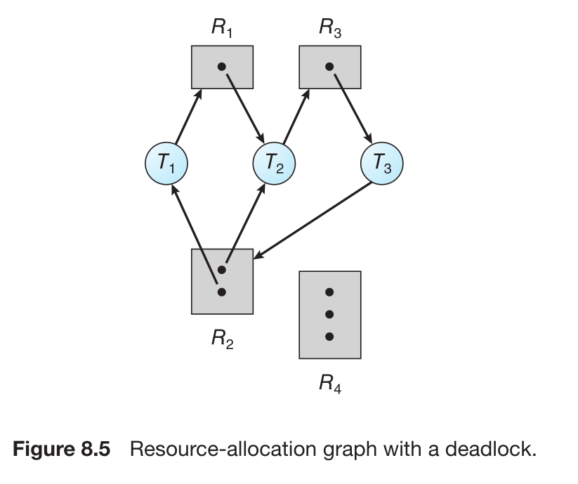

- New edge added: **T₃ → R₂** (a request edge).
- **Now cycles exist:**
  1. T₁ → R₁ → T₂ → R₃ → T₃ → R₂ → T₁
  2. T₂ → R₃ → T₃ → R₂ → T₂
- **Is this a deadlock?** Check resources in the cycles:
  - R₁ has **1 instance**.
  - R₃ has **1 instance**.
  - R₂ has **2 instances**, but **both are already allocated** (to T₁ and T₂). There are no free instances left.
- **Conclusion:** Since R₁ and R³ are single-instance and part of the cycle, and all instances of R₂ are held, this cycle **cannot be broken**. Threads T₁, T₂, and T₃ are **deadlocked**. The cycle here is sufficient to declare deadlock.

**Example 3: Figure 8.6 (Cycle but NO Deadlock)**

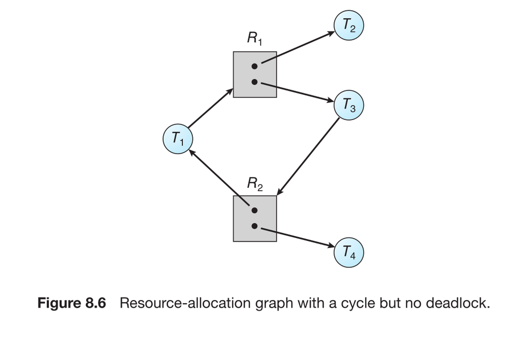

**Go to Figure 8.6.** This graph has a cycle: **T₁ → R₁ → T₃ → R₂ → T₁**.

### Summary of Resource-Allocation Graph Rules

1. **No Cycle → No Deadlock.** (Safe state).
2. **Cycle + All involved resources are single-instance → Deadlock.** (Cycle is necessary and sufficient).
3. **Cycle + Some involved resources have multiple instances → Deadlock *may* exist.** (Cycle is necessary but not sufficient). You must check if existing allocations make the cycle unbreakable.

## 8.4 Methods for Handling Deadlocks

When faced with the deadlock problem, a system designer can choose from three fundamental strategies. The choice involves a trade-off between **performance, convenience, and safety**.

### The Three General Approaches

#### 1. The Ostrich Algorithm: Ignore Deadlocks Entirely

- **Definition:** Pretend that deadlocks never occur. Take **no explicit action** in the OS to prevent, avoid, or detect them.
- **Rationale:** This approach is based on a cost-benefit analysis. Implementing deadlock handling adds **overhead and complexity**. If deadlocks are **very rare** (e.g., once a month or year) and the cost of a system hang is acceptable (a manual reboot), it may be cheaper and simpler to ignore the problem.
- **Consequences:** If a deadlock does occur, it will be **undetected**. The system's performance will degrade (resources locked up, threads stalled) until it eventually **stops functioning completely**, requiring a manual restart.
- **Who Uses This?** This is the approach used by **most general-purpose operating systems**, including **Linux and Windows**. Responsibility is pushed to **kernel and application developers** to write programs that avoid deadlocks using proper design.

#### 2. Ensure Deadlocks Never Happen: Prevention or Avoidance

This proactive approach ensures the system **never enters a deadlocked state**. It has two sub-categories:

- **Deadlock Prevention (Section 8.5):** This is a **static, structural approach**. We design the system so that **at least one of the four necessary conditions for deadlock (Mutual Exclusion, Hold and Wait, No Preemption, Circular Wait) is guaranteed *never* to hold**. This involves imposing **constraints on how resources can be requested** (e.g., a thread must request all resources at once). Prevention is often **restrictive** and can lead to lower resource utilization and system throughput.
- **Deadlock Avoidance (Section 8.6):** This is a **dynamic, runtime approach**. It requires the OS to have **additional advance knowledge** about each thread's future resource needs (maximum claims). For every resource request, the OS performs a **safety check**. It grants the request **only if** doing so leaves the system in a **"safe state"** (a state from which all threads can still *possibly* finish). If granting the request would lead to an "unsafe state" (where deadlock *could* occur later), the requesting thread **must wait**. Avoidance is less restrictive than prevention but requires more runtime overhead and information.

#### 3. Allow Deadlocks, Then Deal With Them: Detection and Recovery

- **Definition:** Allow the system to **enter a deadlocked state**. Periodically, run a **deadlock detection algorithm** (Section 8.7) to examine the system state (e.g., using a resource-allocation graph) to determine if a deadlock has occurred. If a deadlock is found, employ a **recovery algorithm** (Section 8.8) to break it.
- **Recovery Methods:** May involve:
  - **Process/Termination:** Aborting one or more deadlocked threads.
  - **Resource Preemption:** Forcibly taking resources from some threads and giving them to others (requires rollback and careful handling).
- **Who Uses This?** Systems where deadlocks, while undesirable, are an acceptable risk if they can be resolved automatically. This is common in **database management systems**, where the cost of prevention/avoidance is too high, but automatic detection and recovery are feasible.

### Hybrid Approaches and Important Considerations

- **Combining Strategies:** No single approach is perfect for all resource types in an OS. A practical system may use a **hybrid approach**: use prevention for some resources, avoidance for others, and detection/recovery for a third class. The goal is to select the optimal cost/benefit strategy for each class.
- **Deadlocks vs. Other Liveness Failures:** The manual recovery methods a system already needs for other liveness failures (like a high-priority real-time thread hogging the CPU in a non-preemptive system, or livelock) can often be **reused for deadlock recovery**. This makes the "detect and recover" strategy more attractive, as it shares infrastructure with other necessary system functions.
- **The Developer's Role:** In systems using the Ostrich Algorithm (like standard Linux/Windows), the burden falls on **you, the programmer**. When writing multithreaded applications using synchronization tools (mutexes), you **must** employ techniques derived from deadlock prevention (like lock ordering) to ensure your programs are deadlock-free. The OS will not save you.

### Decision Flowchart

In summary, the choice depends on:

1. **How often do deadlocks occur?** (Rare → Ignore)
2. **What is the cost of a deadlock?** (High → Use Prevention/Avoidance)
3. **What is the performance overhead we can tolerate?** (Low overhead → Ignore; Some overhead → Detection/Recovery; Higher overhead → Prevention/Avoidance)
4. **Do we have knowledge of future resource needs?** (Yes → Possible Avoidance; No → Prevention or Detection)

The following sections (8.5 through 8.8) will now dive into the detailed algorithms for **Prevention, Avoidance, Detection, and Recovery**.

## 8.5 Deadlock Prevention

Deadlock prevention is a **strict, static strategy** that aims to **design the system in such a way that it is impossible for a deadlock to ever occur**. Recall the four necessary conditions from Section 8.3.1: Mutual Exclusion, Hold and Wait, No Preemption, and Circular Wait.

**The Prevention Strategy:** For each condition, we devise a **protocol** that **guarantees that condition does NOT hold** in the system. If we can negate *at least one* condition, deadlock becomes impossible. We will now examine each condition and see how we might attack it.

### 8.5.1 Attacking the Mutual Exclusion Condition

- **Goal:** Make it so that resources do *not* require mutual exclusive access; i.e., make all resources **sharable**.
- **Reality Check:** This is **generally impossible** for most physical and logical resources central to deadlock problems.
- **Explanation:**
  - **Sharable Resources:** Some resources *are* inherently sharable and thus **cannot cause deadlock**. A classic example is a **read-only file**. Multiple threads can read from it simultaneously without issue. They never need to wait for exclusive access.
  - **Nonsharable Resources:** The resources that cause deadlock (like **mutex locks, write-access to files, printers**) are **intrinsically nonsharable**. You cannot allow two threads to write to the same file location at the same time without causing corruption. A mutex lock's entire purpose is to provide mutual exclusion for a critical section.
- **Conclusion:** Denying the mutual exclusion condition is **not a viable general-purpose strategy** for deadlock prevention because the core resources we need to manage (synchronization primitives, writeable data) fundamentally require it. **We must look to the other three conditions.**

### 8.5.2 Attacking the Hold and Wait Condition

- **Goal:** Ensure that a thread can **never hold one resource while waiting for another**. This breaks the "hold and wait" state.
- **Method 1: Total Allocation (All Resources Upfront)**
  - **Protocol:** Require each thread to **request and be allocated *all* the resources it will need for its entire execution *before* it is allowed to start**. The thread holds all resources from the beginning.
  - **Problems:**
    1. **Impractical:** It is often impossible for a thread to know all resources it will need in advance. Resource needs are usually **dynamic** (e.g., a thread may need to allocate memory based on user input).
    2. **Severely Lowers Resource Utilization:** Resources are tied up (held idle) for the *entire* duration of the thread's run, even if they are only needed for a short period at the beginning or end. This can lead to massive waste.
    3. **Starvation:** A thread that needs many popular resources may wait forever because it's very unlikely that *all* of them will be free simultaneously.
- **Method 2: All-or-No Resources (Release Before New Request)**
  - **Protocol:** Allow a thread to hold resources, but with a strict rule: **A thread can only request new resources if it currently holds *none***. This means before requesting any new resource, a thread must **first release *all* resources it currently holds**.
  - **How it Breaks Hold & Wait:** A thread is either in a state where it **holds resources (and is not waiting)** or it is **waiting for resources (and holds none)**. It can never be in the hybrid "hold *and* wait" state.
  - **Problems:**
    1. **Low Resource Utilization & Potential Starvation:** Similar to Method 1. A thread needing two resources `A` and `B` must get them simultaneously. If `A` is free but `B` is not, it must release `A` and try again later for both, wasting the opportunity to use `A`.
    2. **Practical Inefficiency:** A thread that constantly needs a core resource (like a lock protecting a frequently accessed data structure) would have to repeatedly acquire and release it, losing progress and adding overhead.

**Summary of Attacking Hold & Wait:** While theoretically possible, protocols to negate this condition are **highly restrictive**, lead to **poor performance and low resource utilization**, and can cause **starvation**. They are rarely used in practice for general-purpose systems.

### 8.5.3 Attacking the No Preemption Condition

- **Goal:** Break the rule that resources cannot be forcibly taken away. Introduce **resource preemption**.
- **Core Idea:** If a thread cannot get what it needs immediately, we can **forcibly take away (preempt) the resources it already holds**. This breaks a potential deadlock by forcing a thread to release resources so others can use them.

Two main protocols implement this idea:

#### Protocol 1: Preempt from the Requester

- **Scenario:** Thread is holding resources and requests a *new* resource that is not immediately available.
- **Action:** **All resources currently held by the requesting thread are implicitly preempted (released).** These preempted resources are added to the list of resources the thread is now waiting for.
- **Restart Condition:** The thread is **not restarted** until it can be allocated **both** the new resource it just requested **and** all of its preempted old resources.
- **Effect:** The thread is temporarily rolled back to a state where it holds nothing, freeing its resources for others.

#### Protocol 2: Preempt from the Holder (Victim Selection)

- **Scenario:** Thread requests a resource.
  1. If available, allocate it.
  2. If **not** available, check: Is it currently held by **another thread that is itself waiting** for some other resource? (i.e., is the holder in a "hold and wait" state?).
     - If **YES**, then **preempt the desired resource from that waiting thread** and give it to the requesting thread.
  3. If the resource is neither available nor held by a waiting thread, the requesting thread must simply wait.
- **While Waiting:** A waiting thread is **vulnerable** to preemption. If another thread requests a resource it holds, that resource may be preempted from it.
- **Restart Condition:** A thread can restart **only when** it is allocated all the new resources it requested **and** has **recovered** any resources that were preempted from it while it was waiting.

#### Practical Application and Severe Limitations

- **Suitable Resources:** This protocol **can only be applied to resources whose state can be easily saved and restored** without catastrophic loss of work.
  - **Good Examples:** **CPU registers** (context switch saves/restores them), **database transactions** (they can be aborted and rolled back), memory pages (can be swapped to disk).
- **Unsuitable Resources (The Big Problem):** The protocol **cannot be applied** to the most common sources of deadlock: **mutex locks and semaphores**.
  - **Why?** Preempting a lock is conceptually meaningless and dangerous. If you forcibly take a lock away from a thread that is in the middle of a critical section, you leave the protected data structure in an **inconsistent, possibly corrupted state**. The thread cannot be rolled back to a point before it acquired the lock without complex and expensive transaction support.
  - **Consequence:** Since deadlocks most frequently involve synchronization primitives (locks), and preemption is not viable for them, **attacking the "No Preemption" condition is often not a practical general solution for deadlock prevention in multithreaded programming.**

**Summary of Attacking No Preemption:** While a valid theoretical approach for certain resource types (like CPU cycles or restartable transactions), it **fails for the very resources (locks) that are most prone to deadlock**. Therefore, like attacking Mutual Exclusion, it is of limited use for preventing the classic deadlocks programmers write in their code.

### 8.5.4 Attacking the Circular Wait Condition

Attacking Mutual Exclusion, Hold and Wait, and No Preemption has proven to be impractical for general use. However, the **Circular Wait** condition offers a **practical and widely used** strategy for deadlock prevention.

#### The Core Idea: Impose a Total Order

- **Goal:** Ensure that a circular chain of waiting threads can never form.
- **Method:**
  1. Define a **total ordering** among all resource types in the system. Assign each resource type a unique integer.
  2. Enforce a protocol: **Threads must request resources in strictly increasing order of their assigned numbers.**

#### Formal Protocol Definition

Let the set of resource types be **R = {R₁, R₂, ..., Rₘ}**. We define a **one-to-one function F: R → N** (where N is natural numbers) that assigns a unique integer to each resource type.

**Protocol Rule:** A thread can request resources **only in an increasing order of enumeration**. More formally:

- A thread can initially request any resource `Rᵢ`.
- After that, the thread can request a resource `Rⱼ` **if and only if** `F(Rⱼ) > F(Rᵢ)`.
- **Alternative Rule (Equivalent):** A thread requesting `Rⱼ` must have **released all resources** `Rᵢ` such that `F(Rᵢ) ≥ F(Rⱼ)`. (You must let go of higher/equal-numbered locks before grabbing new ones).
- **Note:** If a thread needs multiple instances of the *same* resource type, it must request them all at once in a single request.

#### Applying the Protocol to the Pthread Example

Recall **Figure 8.1** (the two-mutex deadlock). We can assign an order:

- `F(first_mutex) = 1`
- `F(second_mutex) = 5`

**The Rule Fixes the Deadlock:** Both `thread_one` and `thread_two` must now request locks in order `first_mutex` (1) then `second_mutex` (5). `thread_two`'s original code (acquiring `second_mutex` first) is **illegal under this protocol**. Once we rewrite both threads to acquire in the same order (1 then 5), the circular wait is broken.

#### Proof: Why This Prevents Circular Wait (By Contradiction)

Assume a circular wait *does* exist despite the protocol. Let the circular wait involve threads `{T₀, T₁, ..., Tₙ}`, where:

- `Tᵢ` is waiting for resource `Rᵢ`, which is held by `Tᵢ₊₁`. (For `Tₙ`, it waits for `Rₙ` held by `T₀`).

Now, analyze each thread `Tᵢ₊₁` in the circle:

- It **holds** resource `Rᵢ`.
- It **is requesting/waiting for** resource `Rᵢ₊₁`.
- By the protocol rule (to hold `Rᵢ` while requesting `Rᵢ₊₁`), we must have: **`F(Rᵢ) < F(Rᵢ₊₁)`**.

This gives us a chain of inequalities for the entire circle: `F(R₀) < F(R₁) < F(R₂) < ... < F(Rₙ) < F(R₀)`.

The final term `F(R₀) < F(R₀)` is a **contradiction** (a number cannot be less than itself). Therefore, our initial assumption is false: **A circular wait cannot exist under this protocol.**

#### Practical Challenges and a Java Solution

- **Challenge 1: Developer Discipline.** The OS does not enforce this. It is **up to the application programmer** to define the order and write code that follows it.
- **Challenge 2: Defining the Order.** In a large system with hundreds of locks, defining and maintaining a global order is difficult.
  - **A Java Trick:** Many Java developers use `System.identityHashCode(Object)` (which returns a unique hash code based on the object's memory address) as the ordering function `F`. The rule becomes: **Always acquire locks in order of increasing `identityHashCode()` of the lock objects.**

#### The Dynamic Locking Problem: Figure 8.7

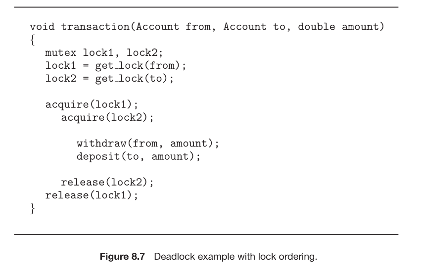

**Go to Figure 8.7.** This shows a critical limitation: lock ordering **fails if locks are acquired dynamically** based on runtime parameters, unless we are very careful.

- **Scenario:** A `transaction()` function transfers money from one account `from` to another `to`. Each account has its own lock, obtained via `get_lock()`.
- **Deadlock Risk:**
  - Thread 1 calls `transaction(checking, savings, 25.0)`. It gets locks in order: `lock1 = checking_lock`, `lock2 = savings_lock`.
  - Thread 2 calls `transaction(savings, checking, 50.0)`. It gets locks in order: `lock1 = savings_lock`, `lock2 = checking_lock`.
- **Result:** The two threads acquire locks in **opposite orders** (`checking→savings` vs `savings→checking`), creating the potential for the classic deadlock from Figure 8.1. The lock order is not fixed at compile time; it depends on the function arguments.

**The Fix (not shown in the book):** To apply the ordering protocol here, we must **compare the two account locks *before* acquisition** and ensure we always acquire the lock with the lower ordering (e.g., lower `identityHashCode`) first. This adds a check:

```
lock1 = get_lock(from);
lock2 = get_lock(to);
if (F(lock1) > F(lock2)) { swap(lock1, lock2); } // Ensure lock1 has lower order
acquire(lock1);
acquire(lock2);
```

**Summary of Attacking Circular Wait:** This is the **most practical and commonly used** technique for deadlock prevention in application programming. It requires developers to impose a total order on resources (locks) and acquire them in that order. It is effective but requires discipline and careful handling of dynamic lock acquisition.

## 8.6 Deadlock Avoidance

### Introduction: The Avoidance Strategy

Deadlock prevention algorithms are **restrictive** because they constrain resource requests to break one of the four necessary conditions, often leading to **low device utilization and reduced system throughput**.

Deadlock avoidance offers a **less restrictive alternative**. It allows more flexibility but requires **additional advance information** about thread behavior. The core idea is to be **cautious**: before granting any resource request, the system performs a runtime check to ensure that granting it will **not potentially lead to a deadlock in the future**.

- **Required Information:** The system needs to know the **complete future sequence of resource requests and releases** for each thread, or at least a summary of it.
- **The Decision:** For each request, the system considers:
  1. Resources **currently available**.
  2. Resources **currently allocated** to each thread.
  3. The **future requests and releases** of each thread.
- **Based on this**, it decides: **Grant the request now** (if it's safe), or **make the thread wait** (to avoid a potential future deadlock).

### The Simplest and Most Useful Model: Maximum Claims

The most common model for avoidance requires each thread to declare its **maximum need** in advance.

- **Declaration:** Each thread states the **maximum number of instances of each resource type** that it may need during its entire execution. This is its **"claim."**
- **Guarantee:** The thread will **never request more than its declared maximum**.
- **Goal:** Using this *a priori* information, the system can run an algorithm that **ensures the system will never enter a deadlocked state**. The algorithm dynamically examines the **resource-allocation state** to guarantee that a **circular-wait condition can never exist**.

### Defining the Resource-Allocation State

The algorithm's decision is based on a complete snapshot of the system called the **resource-allocation state**, which consists of:

1. The number of **available** resources of each type.
2. The number of **allocated** resources of each type to each thread.
3. The **maximum demands** (claims) of each thread.

In the following sections, we will explore two specific deadlock-avoidance algorithms that use this model.

#### Linux Lockdep Tool (Feature Box)

Although ensuring proper lock order is the developer's responsibility, tools can help **verify** that locks are acquired correctly and **detect possible deadlocks**. Linux provides such a tool: **lockdep**.

**Purpose:** lockdep is a sophisticated runtime locking validator used during **development and testing** of the Linux kernel (and recently, user applications with Pthreads). It is **not** for use on production systems, as it adds significant overhead.

**How it Works:** It monitors all lock acquisitions and releases, building a dynamic graph of lock dependencies. It then checks this graph against a set of rules to detect potential deadlock scenarios.

### Two Key Deadlock Detection Capabilities:

1. **Lock Ordering Violations:**
   - lockdep dynamically tracks the **order** in which locks are acquired.
   - If it detects locks being acquired in a different order than they have been in the past, it reports a **possible deadlock condition**. This enforces a consistent global lock order, which is the deadlock prevention technique from Section 8.5.4.
2. **Incorrect Interrupt Handling with Spinlocks:**
   - In the kernel, **spinlocks** (a type of busy-wait lock) are often used in **interrupt handlers**.
   - **Deadlock Scenario:** Kernel code acquires a spinlock. An interrupt occurs on the same CPU, preempting that kernel code. The interrupt handler tries to acquire the **same spinlock**, but finds it already held. It spins forever, causing a deadlock (the kernel code can't run to release the lock because it's preempted).
   - **The Prevention Rule:** Kernel code must **disable local interrupts** on the current processor *before* acquiring a spinlock that could also be used in an interrupt handler.
   - **lockdep's Role:** It detects when interrupts are **enabled** while kernel code acquires a lock that is also used in an interrupt handler, and reports this as a possible deadlock scenario.

**Impact:** Since its introduction in 2006, lockdep has reduced deadlock reports in the Linux kernel by **an order of magnitude**, proving its effectiveness as a development aid.

**For More Information:** See the Linux kernel documentation at `https://www.kernel.org/doc/Documentation/locking/lockdep-design.txt`.

### 8.6.1 Safe State

#### What is a Safe State?

A **safe state** is a system state (a snapshot of current allocations, availability, and maximum claims) from which the system can **guarantee that all threads can complete their work without causing a deadlock**, assuming they eventually request resources up to their declared maximum.

#### The Formal Definition: Safe Sequence

A system is in a safe state **if and only if there exists at least one safe sequence** of threads `<T₁, T₂, ..., Tₙ>`.

**A sequence is safe if for each thread Tᵢ in the sequence, its *future resource needs* can be satisfied by:**

1. The resources **currently available** in the system, **plus**
2. The resources currently held by **all threads Tⱼ that appear *earlier* in the sequence (j < i)**.

**In Practical Terms:** Imagine executing threads in the order of the safe sequence.

- For the **first thread (T₁)** in the sequence: Its remaining needs must be satisfiable **immediately** with currently free resources.
- Once T₁ **finishes** (we assume it will), it releases all its resources.
- Now, with the original free resources **plus** T₁'s resources, the **second thread (T₂)** must be able to have its needs satisfied.
- This process continues until **all threads** in the sequence can finish.

If **no such ordering** of threads exists where each can eventually be satisfied, the system is in an **unsafe state**.

#### Visualizing the Relationship: Safe, Unsafe, and Deadlock States

**Go to Figure 8.8.** This Venn diagram is crucial:

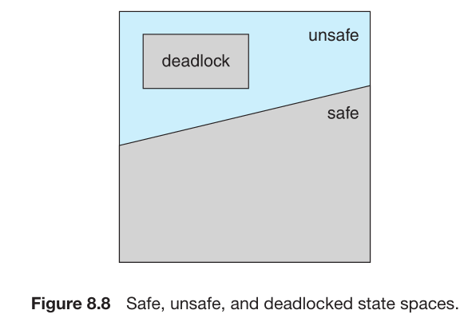

- **Safe State Space:** All system states where **at least one safe sequence exists**.
- **Unsafe State Space:** All system states where **no safe sequence exists**.
- **Deadlock State Space:** A **subset** of the unsafe states. **Every deadlocked state is unsafe**, but **not every unsafe state is deadlocked**.

**Key Insight:** An unsafe state is a **risk zone**. It **may** lead to deadlock **if** threads make unfortunate requests. A safe state is a **guaranteed deadlock-free zone**.

#### Detailed Example: A System with 12 Resources

Let's walk through the book's example step-by-step.

**System Setup:**

- Total Resources: 12 identical instances of one resource type.
- Threads & Maximum Needs:
  - T₀: Maximum 10 resources.
  - T₁: Maximum 4 resources.
  - T₂: Maximum 9 resources.
- **At time t₀ (Initial State):**
  - Allocated: T₀ holds 5, T₁ holds 2, T₂ holds 2.
  - **Available (Free) Resources:** 12 - (5+2+2) = **3**.
  - **Remaining Needs:** Max - Allocated.
    - T₀ Needs: 10 - 5 = **5**
    - T₁ Needs: 4 - 2 = **2**
    - T₂ Needs: 9 - 2 = **7**

**Step 1: Is the state at t₀ Safe?** Yes. Let's find a safe sequence: `< T₁, T₀, T₂ >`.

1. **Check T₁ (Needs 2):** Are 2 resources available? Yes (3 available). T₁ can finish. Assume it does, releasing its 2 held resources. New available = 3 (old) + 2 (T₁'s) = **5**.
2. **Check T₀ (Needs 5):** Are 5 resources available? Yes (5 available). T₀ can finish. It releases its 5 held resources. New available = 5 (old) + 5 (T₀'s) = **10**.
3. **Check T₂ (Needs 7):** Are 7 resources available? Yes (10 available). T₂ can finish.

Since we found a sequence where all threads can complete, the state at **t₀ is SAFE**.

**Step 2: Transition to an Unsafe State.** Now, at time **t₁**, **Thread T₂ requests and is allocated 1 more resource**.

- New Allocation: T₀=5, T₁=2, T₂=**3**.
- New Available: 12 - (5+2+3) = **2**.
- New Remaining Needs:
  - T₀ Needs: 5
  - T₁ Needs: 2
  - T₂ Needs: 9 - 3 = **6**

**Is this new state safe?** Let's try to find *any* safe sequence.

- **Try T₁ first (Needs 2):** 2 available? **Yes**. T₁ finishes, releases 2. New available = 2 + 2 = **4**.
- **Now who's next?**
  - **Try T₀ (Needs 5):** 4 available? **No**. T₀ cannot finish next.
  - **Try T₂ (Needs 6):** 4 available? **No**. T₂ cannot finish next.
- **Conclusion:** After T₁, **neither T₀ nor T₂ can finish** with the available resources. There is **no safe sequence**. Therefore, the state at **t₁ is UNSAFE**.

**The Danger:** In this unsafe state, if T₀ now requests its remaining 5 resources (or T₂ requests 6), they will be blocked because resources are unavailable. This **could lead to a deadlock** (if T₁ finishes, we have 4 free, still not enough for T₀'s 5 or T₂'s 6—both remain blocked forever). The mistake was **granting T₂'s request at t₁**, which moved the system from a **safe** to an **unsafe** state.

### How Avoidance Algorithms Use the Safe State Concept

The core idea of deadlock avoidance is: **Never leave the safe state.**

**Algorithm Outline:**

1. **Start:** Ensure the system is initially in a safe state.
2. **On each resource request:**
   - Check if granting the request would leave the system in a **safe state**.
   - **If YES:** Grant the request immediately.
   - **If NO:** Deny the request and make the thread **wait**, even if the resource is **currently available**.
3. This guarantees the system **always remains in the safe region** of Figure 8.8, avoiding deadlocks.

#### The Trade-off: Lower Resource Utilization

A key consequence of this cautious approach is that a thread may be forced to **wait for a resource that is physically free**. This is because granting it might lead to an unsafe state. This conservative policy means that **resources may be idle more often** (lower utilization) compared to a system without avoidance, but the trade-off is **guaranteed deadlock avoidance**.

### 8.6.2 Resource-Allocation-Graph Algorithm

#### Scope and Prerequisites

This is a deadlock **avoidance** algorithm with a specific limitation: it **only works for resource types that have a single instance each** (e.g., one printer, one scanner, one specific mutex lock). It is a practical application of the safe state concept using a graphical model.

#### Extending the Graph: Claim Edges

We start with the standard Resource-Allocation Graph (RAG) from Section 8.3.2 and add a new type of edge:

- **Claim Edge:** A **dashed line** from a thread `Tᵢ` to a resource `Rⱼ` (**Tᵢ ─ - → Rⱼ**).
- **Meaning:** This edge indicates that thread `Tᵢ` **may request** resource `Rⱼ` at some point in the future. It is a declaration of **potential future need** (part of the "maximum claim" required for avoidance).

#### Graph Transformation Rules (The Lifecycle of an Edge)

The graph evolves dynamically according to strict rules that reflect the thread's lifecycle with a resource:

1. **Initialization (A Priori Claiming):** Before thread `Tᵢ` starts executing, **all its claim edges must be added to the graph**. This is the algorithm's way of knowing the thread's maximum future needs. *(A relaxed rule: a claim edge can be added later, but only if `Tᵢ` currently has no assignment edges—meaning it holds no resources.)*
2. **On a Request:** When thread `Tᵢ` actually requests resource `Rⱼ`, the **dashed claim edge (Tᵢ ─ - → Rⱼ)** is converted into a **solid request edge (Tᵢ ───→ Rⱼ)**.
3. **On a Grant:** When the request is granted, the request edge is converted into an **assignment edge (Rⱼ ───→ Tᵢ)**.
4. **On a Release:** When thread `Tᵢ` releases resource `Rⱼ`, the assignment edge is converted **back** into a **dashed claim edge (Tᵢ ─ - → Rⱼ)**, indicating the thread *could* request it again in the future.

#### The Core Safety Rule: No Cycles Allowed

The entire deadlock avoidance logic is contained in one rule applied when a thread **requests** a resource:

> **A request for resource `Rⱼ` by thread `Tᵢ` can be granted *only if* converting the request edge `Tᵢ → Rⱼ` into an assignment edge `Rⱼ → Tᵢ` would NOT form a cycle in the resource-allocation graph.**
- **How to Check:** Before granting, we **tentatively** add the assignment edge to the graph and run a **cycle-detection algorithm** (complexity O(n²), where *n* is the number of threads).
- **Result:**
  - **If NO cycle is created:** Granting the resource leaves the system in a **safe state**. The request is approved.
  - **If a cycle IS created:** Granting the resource would put the system in an **unsafe state**. The request is **denied**, and the thread must wait, *even if the resource is currently free*.

**Why Does a Cycle Mean Unsafe?** Recall: with single-instance resources, a cycle in the full graph (including assignment edges) is a **sufficient condition for deadlock**. A cycle involving claim/request edges represents a **potential future deadlock**. By blocking the request that would complete the cycle, we prevent the system from ever entering that dangerous, deadlock-prone state.

### Illustrated Example

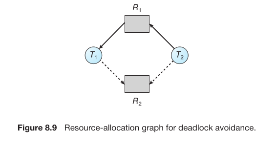

**Go to Figure 8.9.** This shows an initial state. Let's assume it shows:

- Claim edges (dashed lines) indicating future possible requests.
- Some assignment edges (solid lines from resources to threads) showing currently held resources.

**Scenario: Thread T₂ requests resource R₂.**

1. Check: Is R₂ free? Assume it is (no assignment edge from R₂).
2. **Safety Test:** Tentatively convert T₂'s claim edge to R₂ into an assignment edge R₂ → T₂.
3. **Go to Figure 8.10.** This shows the graph *after* the tentative assignment. A **cycle** has appeared (e.g., T₁ → ... → R₂ → T₂ → ... → R₁ → T₁).

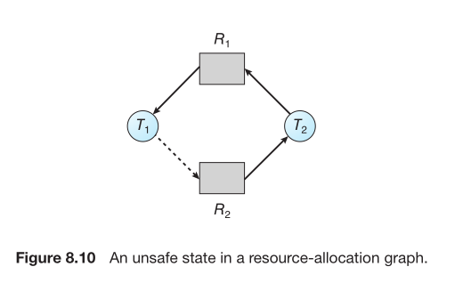

4. **Decision:** Because a cycle forms, granting the request would lead to an **unsafe state**. Therefore, **the request is DENIED**. T₂ must wait for R₂, even though it's free.

**The Danger We Avoided:** If we had granted T₂'s request (putting us in the unsafe state of Figure 8.10), a subsequent request from T₁ for R₂ and T₂ for R₁ could immediately cause a deadlock (a cycle with only assignment and request edges). The algorithm foresees this chain of events and prevents the first step.

#### Summary of the Algorithm

- **Pros:** Intuitive, graphical, and directly implements avoidance for single-instance resources.
- **Cons:**
  1. **Limited Scope:** Only works for single-instance resource types.
  2. **Overhead:** Requires O(n²) cycle detection on *every* resource request.
  3. **Static Claims:** Requires advance knowledge of all possible resource needs (claim edges).
- **It exemplifies the cautious nature of avoidance:** It sometimes says "no" to a currently available resource to maintain a long-term safe state.

### 8.6.3 Banker’s Algorithm

#### Introduction: A More General Algorithm

The Resource-Allocation-Graph algorithm only works for **single-instance** resources. For systems with **multiple identical instances** of each resource type (e.g., 3 printers, 5 tape drives), we need a more general algorithm: the **Banker's Algorithm**.

- **Origin of the Name:** The algorithm mimics a conservative banker who must ensure that, when lending money to customers, they never commit all their cash in a way that prevents them from satisfying the **potential future needs** of *all* customers (which would cause the bank to fail). Similarly, the OS must not allocate resources in a way that could lead to an unsatisfiable future request (a deadlock).
- **Efficiency:** It is **less efficient** (more computationally expensive) than the graph algorithm but handles a broader class of systems.

#### The Setup: Declarations and Data Structures

The algorithm requires **advance knowledge** and maintains several key data structures.

**Prerequisite:** When a thread/process enters the system, it must declare its **maximum demand** for each resource type. This declaration cannot exceed the system's total resources.

**Data Structures:** Let `n` = number of threads, `m` = number of resource types.

1. **Available** (Vector of length `m`): `Available[j] = k` means there are **k free instances** of resource type `Rⱼ` right now.
2. **Max** (n x m matrix): `Max[i][j] = k` means thread `Tᵢ` will **never ask for more than k instances** of resource type `Rⱼ` during its entire run. This is the declared maximum.
3. **Allocation** (n x m matrix): `Allocation[i][j] = k` means thread `Tᵢ` is **currently holding k instances** of `Rⱼ`.
4. **Need** (n x m matrix): `Need[i][j] = k` means thread `Tᵢ` **may still need up to k more instances** of `Rⱼ` to finish its job. Crucially, `Need[i][j] = Max[i][j] - Allocation[i][j]`. This is a **dynamic** value that decreases as the thread gets resources and increases if it releases some before finishing.

#### Vector Notation: A Key Tool

To compare resource allocations and needs, we use **vector comparisons**.

- Let `X` and `Y` be vectors of length `m` (each element represents a resource type).
- **`X ≤ Y`** means **for every index `j`**, `X[j] ≤ Y[j]`. (Every resource count in X is less-than-or-equal to the corresponding count in Y).
- **Example:** If `X = (1,7,3,2)` and `Y = (0,3,2,1)`, then `Y ≤ X` is true because 0≤1, 3≤7, 2≤3, and 1≤2.
- **`X < Y`** means `X ≤ Y` and `X ≠ Y` (at least one element is strictly less).

**Applying to Matrices:** We treat each thread's row in the `Allocation` and `Need` matrices as vectors:

- `Allocationᵢ` = Row `i` of the Allocation matrix = Resources currently held by `Tᵢ`.
- `Needᵢ` = Row `i` of the Need matrix = Future resources `Tᵢ` may still request.

#### The Two Parts of the Banker's Algorithm

The algorithm consists of two distinct routines that are run at different times:

1. **Safety Algorithm:** Determines if the **current system state is safe**. This is run to check the initial state and is the core subroutine called by...
2. **Resource-Request Algorithm:** Run **whenever a thread makes a request**. It simulates granting the request and then uses the **Safety Algorithm** to check if the resulting state would be safe. If safe, it grants the request; if unsafe, it makes the thread wait.

The next sections will detail these algorithms.

#### 8.6.3.1 Safety Algorithm

This algorithm answers the question: **"Is the current system state safe?"** It systematically searches for a **safe sequence** among the threads.

##### Algorithm Steps in Detail

We maintain two working vectors:

- **`Work`** (length `m`): Represents the **projected available resources** as we simulate threads finishing. Initialized to the current `Available` vector.
- **`Finish`** (length `n`): A boolean array where `Finish[i] = true` means we have simulated thread `Tᵢ` finishing its work. Initialized to `false` for all threads.

**Step 1: Initialization.**

- `Work = Available` (Start with what's currently free).
- `Finish[i] = false` for all `i` from `0` to `n-1` (No thread has finished yet in our simulation).

**Step 2: Search for a Thread that Can Finish.** Find an index `i` such that:

- **Condition (a):** `Finish[i] == false` (The thread hasn't been simulated to finish yet).
- **Condition (b):** `Needᵢ ≤ Work` (The thread's **remaining needs** are less than or equal to the **projected available resources**). This means, in our simulation, this thread's future requests could be satisfied immediately.

If **no such thread `i` exists**, go to **Step 4**.

**Step 3: Simulate the Thread Finishing.** Assume thread `Tᵢ` runs to completion. Update our simulation state:

- `Work = Work + Allocationᵢ` (The thread releases all resources it currently holds. Add them to the projected available pool).
- `Finish[i] = true` (Mark this thread as having finished in our simulation).
- Go back to **Step 2** to look for the next thread that can finish with the now larger `Work` vector.

**Step 4: Check the Result.** After the loop ends (when no unfinished thread can satisfy its `Need` from `Work`), check the `Finish` array.

- If **`Finish[i] == true` for all `i`**, then **all threads were able to finish in our simulation**. Therefore, a safe sequence exists, and **the system is in a SAFE state**.
- If **some `Finish[i] == false`**, then those threads could not be guaranteed to finish. **No safe sequence exists**, and the system is in an **UNSAFE state**.

**Complexity:** This algorithm requires **O(m × n²)** operations in the worst case, as we might scan the list of `n` threads up to `n` times (once for each thread we add to the sequence), and each scan involves comparing an `m`-length vector (`Needᵢ ≤ Work`).

#### 8.6.3.2 Resource-Request Algorithm

This algorithm is executed **whenever a thread `Tᵢ` makes a new request for resources**. It decides whether to grant the request immediately or make the thread wait. It uses the **Safety Algorithm** as a subroutine.

Let `Requestᵢ` be the request vector for thread `Tᵢ`. `Requestᵢ[j] = k` means `Tᵢ` wants `k` instances of resource type `Rⱼ`.

##### Algorithm Steps in Detail

**Step 1: Validate the Request Against the Thread's Claim.**

- **Check:** Is `Requestᵢ ≤ Needᵢ`? (Is the request within the thread's declared remaining need?).
- **If NO:** Raise an **error**. The thread is asking for more than it declared it would ever need (violates the `Max` claim).
- **If YES:** Proceed to Step 2.

**Step 2: Check for Immediate Availability.**

- **Check:** Is `Requestᵢ ≤ Available`? (Are there enough free instances of each resource type to satisfy this request right now?).
- **If NO:** The resources are not available. Thread `Tᵢ` must **wait**.
- **If YES:** Proceed to Step 3.

**Step 3: Tentatively Allocate and Test for Safety.** This is the core avoidance step. We **pretend** to grant the request and see if the resulting state is safe.

1. **Tentatively modify the state as if the request was granted:**
   - `Available = Available – Requestᵢ` (Deduct the requested resources from the free pool).
   - `Allocationᵢ = Allocationᵢ + Requestᵢ` (Add the resources to the thread's allocation).
   - `Needᵢ = Needᵢ – Requestᵢ` (Reduce the thread's remaining need).
2. **Run the Safety Algorithm** on this **new, tentative state**.
3. **Make the Decision:**
   - **If the resulting state is SAFE:** The request is **approved**. The tentative changes are made permanent. The transaction is completed, and the thread gets its resources.
   - **If the resulting state is UNSAFE:** The request is **denied**. Thread `Tᵢ` must **wait**. Crucially, we **roll back** the tentative changes, restoring `Available`, `Allocationᵢ`, and `Needᵢ` to their values from **before Step 3**. The system state remains unchanged.

##### Key Points and Implications

- **Wait Even When Resources are Free:** A thread can be made to wait at **Step 2** (resources not free) or at **Step 3** (resources are free, but granting them would lead to an unsafe state). This is the essence of avoidance's conservatism.
- **Ensures Continuous Safety:** By only granting requests that lead to safe states, the algorithm guarantees the system **always remains in the safe region** of the state space (Figure 8.8).
- **Overhead:** The need to run the O(m × n²) Safety Algorithm on **every resource request** makes the Banker's Algorithm too expensive for general use in most OS kernels, but it is a foundational concept and can be used in constrained environments like database systems.

#### 8.6.3.3 An Illustrative Example

This is a complete, numerical walkthrough of the Banker's Algorithm.

##### System Setup

- **Threads:** T₀, T₁, T₂, T₃, T₄ (n=5)
- **Resource Types:** A, B, C (m=3)
- **Total Instances:** A=10, B=5, C=7
- **Current State (Snapshot):**

| Thread | Allocation (A,B,C) | Max (A,B,C) | Need (A,B,C) = Max - Allocation |
| --- | --- | --- | --- |
| T₀ | (0, 1, 0) | (7, 5, 3) | (7, 4, 3) |
| T₁ | (2, 0, 0) | (3, 2, 2) | (1, 2, 2) |
| T₂ | (3, 0, 2) | (9, 0, 2) | (6, 0, 0) |
| T₃ | (2, 1, 1) | (2, 2, 2) | (0, 1, 1) |
| T₄ | (0, 0, 2) | (4, 3, 3) | (4, 3, 1) |

- **Available Vector** (Current Free Resources): `(3, 3, 2)`.
  - **Check:** Sum of Allocations = (7, 2, 5). Total Resources = (10,5,7). So Available = (10-7, 5-2, 7-5) = (3,3,2). Correct.

### Step 1: Is the Initial System State Safe?

We claim it is safe. Let's verify by finding a safe sequence: **< T₁, T₃, T₄, T₂, T₀ >**.

We simulate using the **Safety Algorithm**:

- **Initial:** `Work = Available = (3,3,2)`. `Finish` = [false, false, false, false, false].

**Iteration 1: Find a thread where `Needᵢ ≤ Work`.**

- Check T₁: `Need₁ = (1,2,2)`. Is `(1,2,2) ≤ (3,3,2)`? **Yes** (1≤3, 2≤3, 2≤2). So T₁ can finish.
- Simulate T₁ finishing: `Work = Work + Allocation₁ = (3,3,2) + (2,0,0) = (5,3,2)`. Mark `Finish[1]=true`.

**Iteration 2:** `Work = (5,3,2)`. Find unfinished thread with `Need ≤ Work`.

- Check T₃: `Need₃ = (0,1,1) ≤ (5,3,2)`? **Yes**. T₃ finishes.
- `Work = (5,3,2) + (2,1,1) = (7,4,3)`. `Finish[3]=true`.

**Iteration 3:** `Work = (7,4,3)`.

- Check T₄: `Need₄ = (4,3,1) ≤ (7,4,3)`? **Yes**. T₄ finishes.
- `Work = (7,4,3) + (0,0,2) = (7,4,5)`. `Finish[4]=true`.

**Iteration 4:** `Work = (7,4,5)`.

- Check T₂: `Need₂ = (6,0,0) ≤ (7,4,5)`? **Yes**. T₂ finishes.
- `Work = (7,4,5) + (3,0,2) = (10,4,7)`. `Finish[2]=true`.

**Iteration 5:** `Work = (10,4,7)`.

- Check T₀: `Need₀ = (7,4,3) ≤ (10,4,7)`? **Yes**. T₀ finishes.
- `Work = (10,4,7) + (0,1,0) = (10,5,7)`. `Finish[0]=true`.

**Final Check:** All `Finish[i]` are true. **The state is SAFE.** The safe sequence is `<T₁, T₃, T₄, T₂, T₀>`.

##### Step 2: Handling a Resource Request

Now, **Thread T₁ makes a request: `Request₁ = (1, 0, 2)`.**

We follow the **Resource-Request Algorithm**:

**Step 1: Validate against Need.** `Request₁ = (1,0,2)`. `Need₁ = (1,2,2)`. Is `(1,0,2) ≤ (1,2,2)`? **Yes** (1≤1, 0≤2, 2≤2). Request is within declared needs.

**Step 2: Check against Available.** `Available = (3,3,2)`. Is `(1,0,2) ≤ (3,3,2)`? **Yes** (1≤3, 0≤3, 2≤2). Resources are free.

**Step 3: Tentative Allocation and Safety Check.**

1. Pretend to allocate:
   - `Available = (3,3,2) - (1,0,2) = (2,3,0)`
   - `Allocation₁ = (2,0,0) + (1,0,2) = (3,0,2)`
   - `Need₁ = (1,2,2) - (1,0,2) = (0,2,0)`
2. New Tentative State:

| Thread | Allocation | Need | Available = (2,3,0) |
| --- | --- | --- | --- |
| T₀ | (0,1,0) | (7,4,3) |  |
| T₁ | **(3,0,2)** | **(0,2,0)** |  |
| T₂ | (3,0,2) | (6,0,0) |  |
| T₃ | (2,1,1) | (0,1,1) |  |
| T₄ | (0,0,2) | (4,3,1) |  |

3. **Run Safety Algorithm on this new state** to see if it's safe.
   - `Work = (2,3,0)`, `Finish` all false.
   - Find thread with `Need ≤ Work`. T₁'s new `Need₁=(0,2,0) ≤ (2,3,0)`? **Yes**. Simulate T₁ finish: `Work = (2,3,0)+(3,0,2)=(5,3,2)`. `Finish[1]=true`.
   - `Work=(5,3,2)`. T₃: `Need₃=(0,1,1) ≤ (5,3,2)`? **Yes**. `Work=(5,3,2)+(2,1,1)=(7,4,3)`. `Finish[3]=true`.
   - `Work=(7,4,3)`. T₄: `Need₄=(4,3,1) ≤ (7,4,3)`? **Yes**. `Work=(7,4,3)+(0,0,2)=(7,4,5)`. `Finish[4]=true`.
   - `Work=(7,4,5)`. T₀: `Need₀=(7,4,3) ≤ (7,4,5)`? **Yes**. `Work=(7,4,5)+(0,1,0)=(7,5,5)`. `Finish[0]=true`.
   - `Work=(7,5,5)`. T₂: `Need₂=(6,0,0) ≤ (7,5,5)`? **Yes**. `Work=(7,5,5)+(3,0,2)=(10,5,7)`. `Finish[2]=true`.

   All threads finished. **The new state is SAFE** (sequence `<T₁, T₃, T₄, T₀, T₂>` works).

**Conclusion:** Since the tentative state is safe, the request is **GRANTED**. The new system state becomes the one we calculated above.

**Programming Exercise:** Implementing this algorithm is an excellent way to understand its mechanics fully.

## 8.7 Deadlock Detection

### Introduction: The Detection and Recovery Strategy

This is the third major strategy for handling deadlocks (after Ignoring, and Prevention/Avoidance). It involves two distinct phases:

1. **Detection Algorithm:** Periodically examine the system state to determine **if a deadlock has already occurred**.
2. **Recovery Algorithm:** If a deadlock is detected, take action to **break it** (e.g., abort threads, preempt resources).

**Important Trade-off:** This scheme introduces **overhead**:

- **Runtime Costs:** Maintaining state information and periodically executing the detection algorithm consumes CPU cycles.
- **Recovery Losses:** Recovering from a deadlock often involves rolling back or terminating threads, which means losing work.

We will examine detection algorithms for two scenarios: (1) systems where each resource has a **single instance**, and (2) systems with **multiple instances** of each resource type.

### 8.7.1 Single Instance of Each Resource Type

For systems where each resource type has exactly one instance (e.g., one scanner, one specific lock), we can use a simplified version of the resource-allocation graph called the **Wait-For Graph**.

#### Constructing the Wait-For Graph

**Go to Figure 8.11.** This shows the transformation.

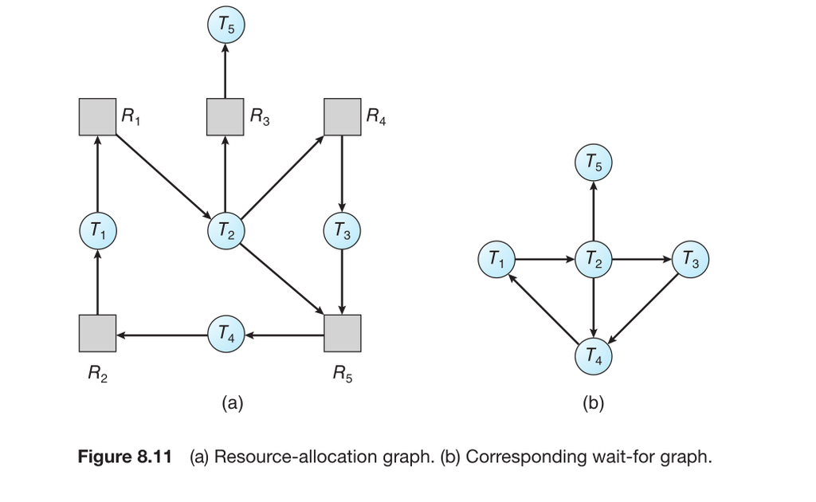

- **(a) Resource-Allocation Graph (RAG):** The standard graph with thread nodes (circles) and resource nodes (rectangles), connected by request and assignment edges.
- **Transformation Rule:** To create the **Wait-For Graph**:
  1. **Remove all resource nodes (rectangles).**
  2. **Collapse the edges.** For any resource node `R_q` that has an incoming request edge from thread `T_i` and an outgoing assignment edge to thread `T_j`, create a **directed edge `T_i → T_j`** in the wait-for graph.
- **Interpretation of an Edge `T_i → T_j`:** Thread `T_i` is **waiting for** thread `T_j` to release a specific resource that `T_i` needs.

#### Practical Tool: The BCC `deadlock_detector`

The **BPF Compiler Collection (BCC)** toolkit for Linux (introduced in Section 2.10.4) includes a practical tool for deadlock detection in user-space Pthreads programs.

- **How it Works:** It uses dynamic tracing to insert probes (hooks) into the `pthread_mutex_lock()` and `pthread_mutex_unlock()` function calls in a target process.
- **Action:** Whenever the traced process calls these functions, the `deadlock_detector` tool **constructs a real-time wait-for graph** of the mutex locks in that process.
- **Detection:** It analyzes this graph and **reports a potential deadlock if it detects a cycle**.
- **Purpose:** This is a **debugging and development tool**, not a production runtime deadlock solver. It helps programmers identify code paths that can lead to deadlock.

**Summary for Single-Instance Resources:** Detection is conceptually straightforward—maintain a wait-for graph and look for cycles. The challenge lies in the overhead of maintaining the graph and running the cycle detection algorithm.

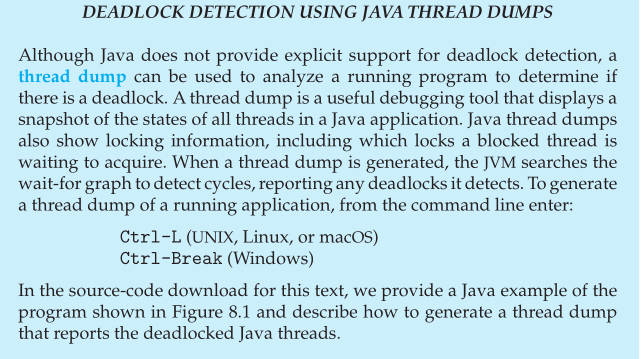

## 8.7.2 Several Instances of a Resource Type

The Wait-For Graph method doesn't work when resources have multiple instances. For these systems, we need a detection algorithm that closely resembles the **Banker's Algorithm**, but with a crucial difference in purpose: the Banker's Algorithm **prevents** unsafe states, while this algorithm **detects** actual deadlocks after they may have occurred.

### Data Structures

We maintain three key data structures, similar to the Banker's algorithm:

- **`Available`**: Vector of length `m`. `Available[j] = k` means `k` instances of resource type `Rⱼ` are currently **free**.
- **`Allocation`**: `n x m` matrix. `Allocation[i][j] = k` means thread `Tᵢ` currently holds `k` instances of `Rⱼ`.
- **`Request`**: `n x m` matrix. `Request[i][j] = k` means thread `Tᵢ` is **currently blocked, waiting for** `k` more instances of `Rⱼ`. *(This is different from the Banker's `Need` matrix, which was a future maximum. `Request` is the **current, outstanding** request that caused the thread to wait.)*

We treat rows as vectors: `Allocationᵢ`, `Requestᵢ`. The `≤` relation for vectors is defined as before.

### The Deadlock Detection Algorithm

This algorithm simulates a **selective reduction** of the system. It tries to find an order in which **blocked threads could eventually complete**, assuming they get the resources they're waiting for. Threads that are **not blocked** are assumed to finish quickly and release their resources.

**Step 1: Initialization.**

- `Work = Available` (Start with currently free resources).
- For each thread `Tᵢ`:
  - If `Allocationᵢ != 0` (the thread holds some resources), set `Finish[i] = false`. (We need to check if it can finish).
  - If `Allocationᵢ == 0` (the thread holds **no** resources), set `Finish[i] = true`. (A thread with no resources cannot be part of a resource deadlock. It may be runnable or waiting for an event, but not waiting for resources held by others.)

**Step 2: Find a Thread That Could Be Satisfied.** Find an index `i` such that:

- (a) `Finish[i] == false` (Thread is still under consideration).
- (b) `Requestᵢ ≤ Work` (The thread's **current waiting request** can be satisfied by the currently available resources in our simulation).

If **no such `i` exists**, go to **Step 4**.

**Step 3: Simulate Thread Completion.** Assume `Tᵢ` gets its requested resources, finishes its task, and releases **all** its held resources.

- `Work = Work + Allocationᵢ` (Add `Tᵢ`'s held resources to the free pool).
- `Finish[i] = true`.
- Go back to **Step 2**.

**Step 4: Analyze the Results.** After the loop ends (no more threads satisfy condition 2b), examine the `Finish` array.

- If **`Finish[i] == false` for some `i`**, then thread `Tᵢ` is **deadlocked**. The set of all threads with `Finish[i] == false` is the deadlocked set.
- If **`Finish[i] == true` for all `i`**, then **no deadlock exists**. The sequence of threads we marked `true` in Step 3 represents an order in which all threads could have completed, so the system state was not deadlocked.

**Complexity:** **O(m × n²)** operations, same as the Safety Algorithm.

### Why the Algorithm Works: The "Optimistic Assumption"

A key point in **Step 3**: We immediately reclaim a thread's resources once we see its `Requestᵢ ≤ Work`. Why?

- **Reasoning:** If a thread's current request can be satisfied (`Requestᵢ ≤ Work`), it is **not currently deadlocked** in our simulation snapshot. We make the **optimistic assumption** that this thread will proceed, finish quickly, and free its resources. This allows our simulation to "unlock" more resources for other threads.
- **If the assumption is wrong** (e.g., the thread immediately requests more resources after the ones we just gave it), that new request could cause a deadlock **later**. Our algorithm is a **snapshot detection**; that later deadlock will be caught the **next time** the detection algorithm is run.

### Illustrated Example

**System:** 5 threads (T₀..T₄), 3 resource types (A, B, C). Total: A=7, B=2, C=6.

**Snapshot 1: (No Deadlock)** Given State:

- **Allocation Matrix:**
  - T₀: (0,1,0)
  - T₁: (2,0,0)
  - T₂: (3,0,3)
  - T₃: (2,1,1)
  - T₄: (0,0,2)
- **Request Matrix (Current Outstanding Requests):**
  - T₀: (0,0,0) → *Not blocked, requesting nothing.*
  - T₁: (2,0,2) → *Blocked, waiting for 2 A and 2 C.*
  - T₂: (0,0,0) → *Not blocked.*
  - T₃: (1,0,0) → *Blocked, waiting for 1 A.*
  - T₄: (0,0,2) → *Blocked, waiting for 2 C.*
- **Available Vector:** `(0,0,0)` (All resources are allocated).

**Run the Detection Algorithm on Snapshot 1:**

1. `Work = (0,0,0)`. `Finish` = [false, false, false, false, false] (all threads hold resources, so all initially false).
2. Find `i` where `Finish[i]==false` and `Requestᵢ ≤ Work`.
   - T₀: `Request₀=(0,0,0) ≤ (0,0,0)`? **Yes**.
   - (We find T₀ first. Could also find T₂, which also has `Request=(0,0,0)`).
3. Simulate T₀ finish: `Work = (0,0,0) + Allocation₀ = (0,0,0)+(0,1,0) = (0,1,0)`. `Finish[0]=true`.
4. Back to Step 2: `Work=(0,1,0)`. Find next `i`. T₂: `Request₂=(0,0,0) ≤ (0,1,0)`? **Yes**. Simulate T₂: `Work = (0,1,0)+(3,0,3) = (3,1,3)`. `Finish[2]=true`.
5. `Work=(3,1,3)`. Find next. T₃: `Request₃=(1,0,0) ≤ (3,1,3)`? **Yes**. Simulate T₃: `Work = (3,1,3)+(2,1,1) = (5,2,4)`. `Finish[3]=true`.
6. `Work=(5,2,4)`. Find next. T₁: `Request₁=(2,0,2) ≤ (5,2,4)`? **Yes**. Simulate T₁: `Work = (5,2,4)+(2,0,0) = (7,2,4)`. `Finish[1]=true`.
7. `Work=(7,2,4)`. Find last. T₄: `Request₄=(0,0,2) ≤ (7,2,4)`? **Yes**. Simulate T₄: `Work = (7,2,4)+(0,0,2) = (7,2,6)`. `Finish[4]=true`.
8. Step 4: All `Finish[i]` are true. **No deadlock.** The sequence `<T₀, T₂, T₃, T₁, T₄>` is a feasible completion order.

**Snapshot 2: (Deadlock Introduced)** Now, **Thread T₂ makes an additional request for 1 instance of C**.

- New **Request Matrix:** T₂'s row changes from `(0,0,0)` to `(0,0,1)`.
- Now, T₂ is **blocked waiting for 1 C**.

**Run the Detection Algorithm on Snapshot 2:**

1. `Work = (0,0,0)`. `Finish` all false.
2. Find `i` where `Finish[i]==false` and `Requestᵢ ≤ Work`.
   - Check T₀: `(0,0,0) ≤ (0,0,0)`? **Yes**. Simulate T₀ finish. `Work = (0,1,0)`. `Finish[0]=true`.
3. Now `Work=(0,1,0)`. Find next `i`.
   - Check T₁: `(2,0,2) ≤ (0,1,0)`? **No**.
   - Check T₂: `(0,0,1) ≤ (0,1,0)`? **No** (needs 1 C, but 0 C available).
   - Check T₃: `(1,0,0) ≤ (0,1,0)`? **No** (needs 1 A, but 0 A available).
   - Check T₄: `(0,0,2) ≤ (0,1,0)`? **No**.
4. **No thread satisfies condition 2b.** Go to Step 4.
5. `Finish` is false for T₁, T₂, T₃, T₄. **The system is deadlocked.** Threads T₁, T₂, T₃, and T₄ are in the deadlock set. (T₀ is not deadlocked; it could have run).

**Conclusion:** The algorithm successfully identified the deadlock in the second scenario by simulating resource reclamation and finding that a set of threads could not make progress.

### 8.7.3 Detection-Algorithm Usage

A critical practical question: **How often should we run the deadlock detection algorithm?**

The frequency is a trade-off based on two key factors:

1. **How often do deadlocks occur?** (Frequency)
2. **How many threads are impacted when a deadlock happens?** (Severity)

#### Strategy 1: Detect on Every Blocking Request (Extreme, Precise)

- **Method:** Invoke the detection algorithm **every time a thread makes a resource request that cannot be granted immediately** (i.e., the thread is about to block).
- **Advantages:**
  - **Immediate Detection:** You detect a deadlock **the instant it occurs**.
  - **Identifies the "Trigger":** You can pinpoint the **specific thread and request** that completed the wait cycle and caused the deadlock. (Though technically, all threads in the cycle jointly caused it).
- **Disadvantage:**
  - **Massive Overhead:** Running an O(n²) algorithm on *every* blocking request can severely degrade system performance, especially in busy systems.

#### Strategy 2: Periodic Detection (Practical, Common)

- **Method:** Invoke the detection algorithm at **regular intervals** (e.g., every few minutes, every hour) or based on a **system performance heuristic**.
- **Common Heuristic:** Run detection when **CPU utilization drops below a threshold** (e.g., 40%). The rationale is that a deadlock will eventually cause threads to stall, reducing useful work and lowering CPU utilization.
- **Advantages:**
  - **Lower Overhead:** Significantly reduces computational cost compared to per-request detection.
- **Disadvantages:**
  - **Delayed Detection:** A deadlock may exist for some time before being detected, leaving resources idle.
  - **Cannot Identify the Cause:** By the time the algorithm runs, the resource graph may contain multiple cycles. It's impossible to tell which particular request was the final trigger; you only see the resulting deadlocked set.

#### Choosing the Right Frequency

- **If deadlocks are frequent:** Detection must be invoked **more often** to minimize resource idle time and prevent the deadlock from growing (more threads might become involved).
- **If deadlocks are rare:** You can afford to run detection **less frequently** (e.g., periodically) to save on overhead.

#### Feature Box: Managing Deadlock in Databases

Database systems are a prime real-world example of the **detect-and-recover** strategy in action.

- **Why Deadlocks Happen:** Database operations are performed as **transactions** that acquire **locks** on data items (rows, tables) to ensure consistency. With multiple concurrent transactions, deadlock is a common risk.
- **Detection:** The database server periodically (not on every lock wait) **searches for cycles in a wait-for graph** representing transactions waiting for locks.
- **Recovery:** Upon detection, the system:
  1. **Selects a Victim:** Chooses a transaction to abort (e.g., MySQL picks the transaction with the minimal number of affected rows to reduce rollback cost).
  2. **Performs Rollback:** Aborts the victim transaction, which releases **all its locks**.
  3. **Allows Others to Proceed:** The remaining transactions are now free from deadlock and can resume.
  4. **Reissues the Victim:** The aborted transaction is typically restarted from the beginning by the application or database driver.
- **This model works well** because transactions are designed to be **atomic** and support rollback, making recovery feasible.

**Key Insight:** The choice of detection frequency is an **engineering compromise**. No single answer is correct for all systems. It depends on the cost of deadlock versus the cost of detection.

## 8.8 Recovery from Deadlock

Once a deadlock is detected, the system must **recover** from it. There are two broad approaches:

1. **Manual Recovery:** Inform a human operator and let them handle it (e.g., through system commands).
2. **Automatic Recovery:** The operating system itself breaks the deadlock using one of two fundamental techniques:
   - **Terminate** one or more deadlocked threads/processes.
   - **Preempt** resources from one or more deadlocked threads.

We will focus on automatic recovery methods.

### 8.8.1 Process and Thread Termination

This method breaks a deadlock by **selectively killing** deadlocked threads/processes, thereby releasing all their held resources and breaking the circular wait.

#### Two Termination Strategies:

**1. Terminate All Deadlocked Processes:**

- **Action:** Abort **every** process/thread that is part of the deadlock cycle.
- **Advantage:** Guaranteed to break the deadlock quickly and simply.
- **Disadvantage:** **Extremely costly**. These processes may have been running for a long time; their partial computations are **lost entirely** and must be redone from scratch. This represents a huge waste of work.

**2. Terminate One Process at a Time:**

- **Action:** Abort **one** deadlocked process, release its resources, then **re-run the deadlock detection algorithm** to see if the deadlock is resolved.
- **Process:** Repeat (select another victim, abort, re-detect) until the deadlock cycle is finally broken.
- **Advantage:** Potentially **minimizes the amount of lost work**, as you might only need to abort one or a few processes.
- **Disadvantage:** **High overhead** because the detection algorithm (O(n²)) must be run **after each termination** to re-evaluate the system state.

#### The Practical Challenge of Termination

Aborting a process is **not a clean "undo."** It can leave the system in an **inconsistent state**:

- **Files:** If the process was halfway through writing a file, the file may be corrupted or left with partial, meaningless data.
- **Shared Data & Locks:** If the process was holding a mutex lock while modifying shared data structures, aborting it will force the OS to mark the lock as **available**, but the **shared data itself may be left in a corrupted, partially updated state**. This can break other processes.

#### Choosing the "Best" Victim: A Cost-Based Policy

When using the "one at a time" method, a critical decision is: **Which deadlocked process should we terminate first?** This is a **policy decision** (like CPU scheduling) based on minimizing **"cost."** Factors to consider include:

1. **Process Priority:** Terminate a low-priority process before a high-priority one.
2. **Computation Time Invested:** How long has the process been running? Terminating a process that is 99% done is more wasteful than terminating one that just started. (But you also need to consider how much longer it *would* run if allowed to live).
3. **Resource Types Held:** Are the resources held by the process **easy to preempt and restore**? Terminating a process holding simple resources is better than terminating one holding complex, stateful resources.
4. **Future Resource Needs:** How many more resources does the process need to finish? A process that is almost done (needs few resources) might be a poor victim, as it's close to releasing everything.
5. **Cascading Termination:** How many *other* processes will need to be terminated if this one is killed? (e.g., if this process is a parent or is communicating with others). The goal is to minimize the **total number of terminated processes**.

The OS must implement a heuristic or cost function that weighs these factors to select the **least costly victim**.

### 8.8.2 Resource Preemption

This recovery method breaks deadlocks by **forcibly taking away (preempting)** resources from some deadlocked threads and giving them to others, thereby breaking the circular wait. It's less drastic than outright termination but introduces significant complexity.

### Three Critical Issues to Address:

#### 1. Selecting a Victim

We must decide **which resource(s)** and **from which thread(s)** to preempt.

- **Goal:** Minimize the **"cost"** of preemption.
- **Cost Factors** are similar to termination and may include:
  - **Number and Type of Resources Held:** Preempting a single, simple resource is cheaper than preempting several complex ones.
  - **Amount of Computation Time Already Invested:** Preempting from a thread that has run for a long time may waste more work if it has to roll back far.
  - **Progress to Completion:** A thread close to finishing might be a poor victim.
- The system uses these factors to pick the **least costly victim thread and resource combination**.

#### 2. Rollback

Once a resource is preempted from a thread, **what happens to that thread?** It cannot proceed normally because it's now missing a resource it needs.

- **The Core Problem:** We must **roll the thread back** to a previous, **safe state** from which it can restart, hopefully without the same deadlock recurring.
- **What is a Safe State?** It's a state (a snapshot of the thread's memory, registers, and resource holdings) that is **consistent and correct** to restart from. Determining this automatically is very difficult.
- **Common (Simple) Solution: Total Rollback.** **Abort the victim thread completely** and restart it from the beginning. This is essentially termination + restart. It's simple but wastes all the work the thread did up to that point.
- **More Sophisticated (Complex) Solution: Partial Rollback.** Roll the thread back **only far enough** to a known checkpoint before it acquired the preempted resource, then restart from there. This requires the system to **maintain detailed logs (checkpoints)** of each thread's state over time, which adds significant memory and runtime overhead.

#### 3. Starvation

- **The Problem:** If victim selection is purely based on a static cost factor (e.g., "always preempt from the thread holding the fewest resources"), the **same thread** could be **repeatedly** chosen as the victim. It would never make progress, leading to **starvation**.
- **The Solution:** The victim selection policy must **guarantee that no thread is picked as a victim indefinitely**.
- **Practical Implementation:** Include the **number of times a thread has already been rolled back due to preemption** as a **cost factor** in the selection algorithm. As a thread's rollback count increases, its effective "cost" for being chosen again should **increase dramatically**, making it less likely to be selected repeatedly. This ensures **fairness** and prevents starvation.

### Summary of Recovery Methods

- **Termination** is simpler but **destructive** (loses work, risks data corruption).
- **Resource Preemption** is more flexible but **complex**, requiring solutions for victim selection, rollback, and starvation prevention. It is most feasible in systems that already support **transactions and checkpointing** (like databases).

## 8.9 Summary

### Core Concepts

- **Definition:** A deadlock is a state where **every process/thread in a set** is waiting for an event (typically resource acquisition) that can **only be caused by another member of the same set**. The system grinds to a halt.
- **Necessary Conditions:** All four must hold simultaneously for a deadlock to be possible:
  1. **Mutual Exclusion:** Resources are non-sharable.
  2. **Hold and Wait:** A thread holds resources while waiting for others.
  3. **No Preemption:** Resources cannot be forcibly taken away.
  4. **Circular Wait:** A circular chain of waiting threads exists.

### Models and Tools

- **Resource-Allocation Graph (RAG):** A directed graph model used to visualize resource allocation and requests. For **single-instance** resource types, a **cycle in the graph is both necessary and sufficient for deadlock**.
- **Wait-For Graph:** A simplified RAG used for deadlock **detection** in single-instance systems. A cycle indicates deadlock.

### Strategies for Handling Deadlocks

The chapter presented three overarching strategies, each with specific techniques:

#### 1. Deadlock Prevention

- **Goal:** Design the system so deadlock is **structurally impossible**.
- **Method:** Negate at least one of the four necessary conditions.
- **Most Practical Method:** **Negate Circular Wait** by imposing a **total ordering** on all resource types and requiring that resources be requested in **strictly increasing order**. This is the primary technique programmers use to write deadlock-free multithreaded code.

#### 2. Deadlock Avoidance

- **Goal:** Allow more flexibility than prevention, but **dynamically deny** requests that could lead to a future deadlock.
- **Requirement:** Advance knowledge of each thread's **maximum resource needs**.
- **Key Algorithm:** The **Banker's Algorithm**.
  - It maintains data structures (`Available`, `Max`, `Allocation`, `Need`).
  - Defines a **safe state** (where a safe sequence of thread completions exists).
  - On each request, it performs a **safety check** and only grants the request if the resulting state remains **safe**. It may deny a request even if resources are free.
- **Trade-off:** Safer than ignoring deadlocks, but incurs significant runtime overhead.

#### 3. Deadlock Detection and Recovery

- **Goal:** Allow deadlocks to occur, then **identify and break them**.
- **Detection:** Algorithms periodically examine system state.
  - For **single-instance** resources: Use cycle detection in the wait-for graph.
  - For **multiple-instance** resources: Use an algorithm similar to the Banker's, but using the current `Request` matrix instead of future `Need`.
- **Recovery:** Two main methods once deadlock is detected:
  1. **Process/Termination:** Abort one or more deadlocked threads. Requires a **victim selection** policy based on minimizing cost.
  2. **Resource Preemption:** Forcibly take resources from some threads and give to others. Must solve **victim selection**, **rollback** (to a safe state), and **starvation prevention**.

### Practical Reality

- Most general-purpose operating systems (Linux, Windows) use **no automatic deadlock handling** in the kernel for user processes—they effectively **ignore** the problem due to performance overhead.
- Therefore, the responsibility falls on **application developers** to use **prevention techniques** (especially lock ordering) to write correct, deadlock-free concurrent programs.
- Specialized systems like **databases** successfully employ the **detect-and-recover** strategy, leveraging transactional rollback for recovery.

**Key Takeaway:** Deadlock is a fundamental challenge in concurrency. Understanding its conditions provides the tools to prevent it in code, while the algorithms (Banker's, detection) provide theoretical and specialized practical solutions for automated management.